# Visualización de datos

Vane Figueroa Robles

26/3/2022

[Ver Repositorio en GitHub](https://github.com/VaneFigueroa/Statistical-Inference.git)

[Atrás](https://vanefigueroa.github.io/Manipulacion-y-visualizacion/)

[Inicio](https://vanefigueroa.github.io/Portwebsite.github.io/)

## Visualización

> “Un simple gráfico ha brindado más información a la mente del analista de datos que cualquier otro dispositivo”. — John Tukey

En este proyecto, se desarrolla las actividades propuestas en [R for Data Science](https://es.r4ds.hadley.nz/index.html) de Hadley Wickham y Garrett Grolemund.

De los muchos sistemas que posee R para hacer gráficos, ggplot2 es uno de los más elegantes y versátiles. Se indaga las funciones de este paquete, examina la gramática de gráficos, y recursos disponibles para la desafiante tarea de visuliazación de datos.

## Primeros Pasos

##### 3.2.4 Ejercicios

1. Ejecuta ggplot(data = millas). ¿Qué observas? Con este comando, se obtiene un gráfico vacío.

```r
ggplot(data = millas)
```

2. ¿Cuántas filas hay en millas? ¿Cuántas columnas? Hay 234 filas y 11 columnas

```r
dim(millas)
```

```
## [1] 234  11
```

3. ¿Qué describe la variable traccion? Lee la ayuda de ?millas para encontrar la respuesta. Describe el tipo de tracción; d = delantera, t = trasera, 4 = 4 ruedas

```r
?millas
```

4. Realiza un gráfico de dispersión de autopista versus cilindros.

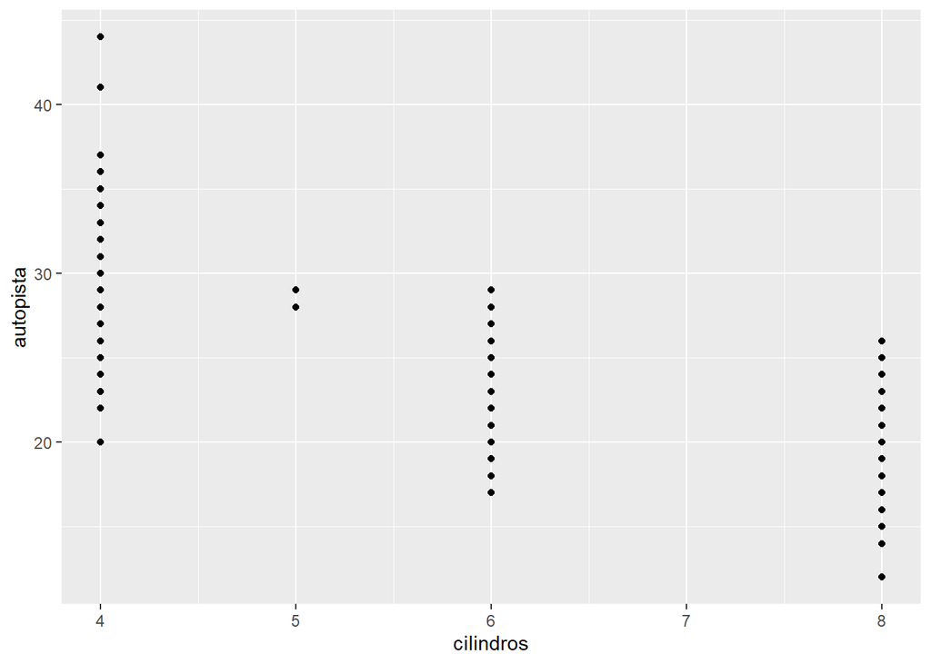

```r
ggplot(data = millas) +
  geom_point(mapping = aes(x =cilindros , y = autopista))
```

5. ¿Qué sucede cuando haces un gráfico de dispersión (scatterplot) de clase versus traccion? ¿Por qué no es útil este gráfico? Clase y tracción son variables categóricas. El gráfico de dispersión no es el gráfico adeacuado para este tipo de variables.

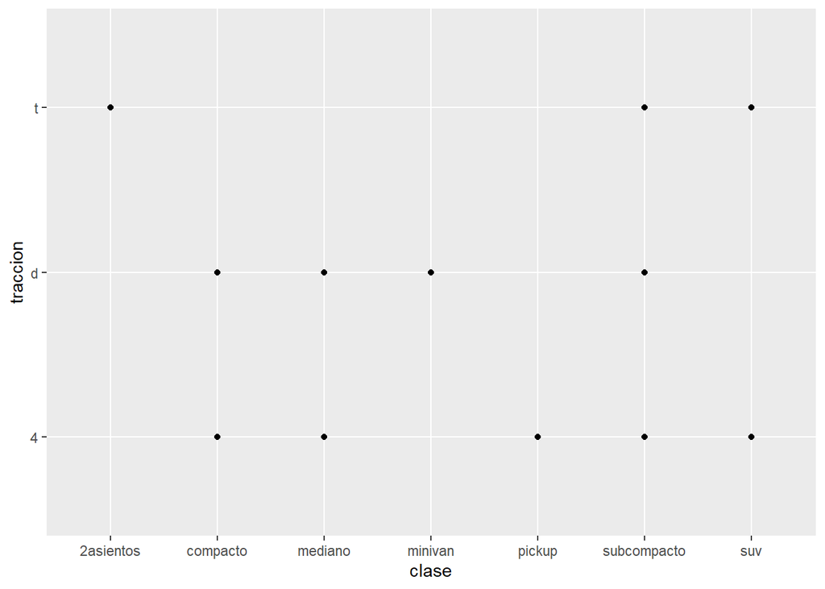

```r
ggplot(data = millas) +
  geom_point(mapping = aes(x =clase , y = traccion))
```

## Mapeos estéticos

##### 3.3.1 Ejercicios

1. ¿Qué no va bien en este código? ¿Por qué hay puntos que no son azules? Porque el color se encuentra dentro del parentesis de aes.

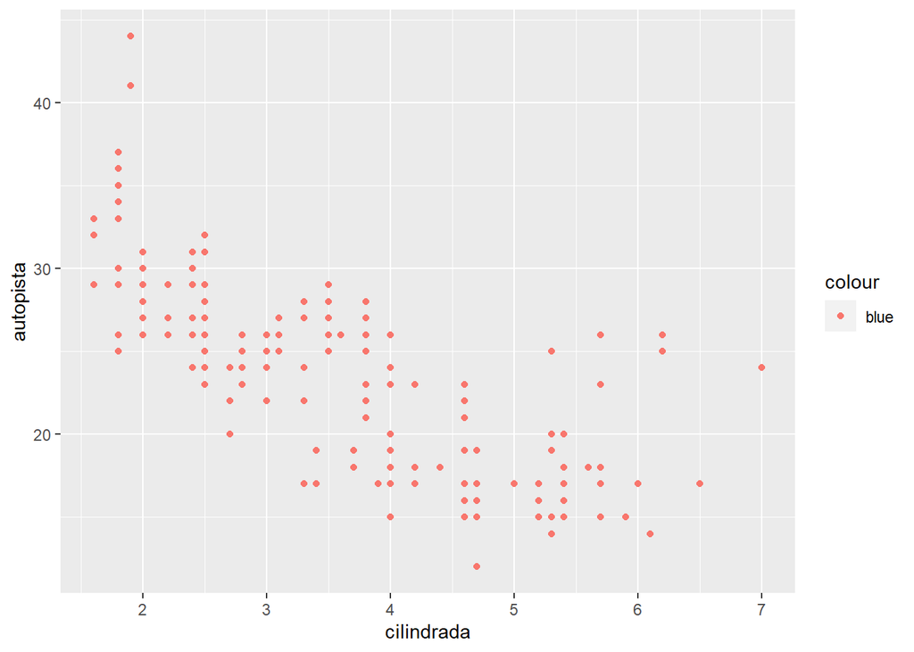

```r
ggplot(data = millas) +
   geom_point(mapping = aes(x = cilindrada, y = autopista, color = "blue"))
```

Para corregir:

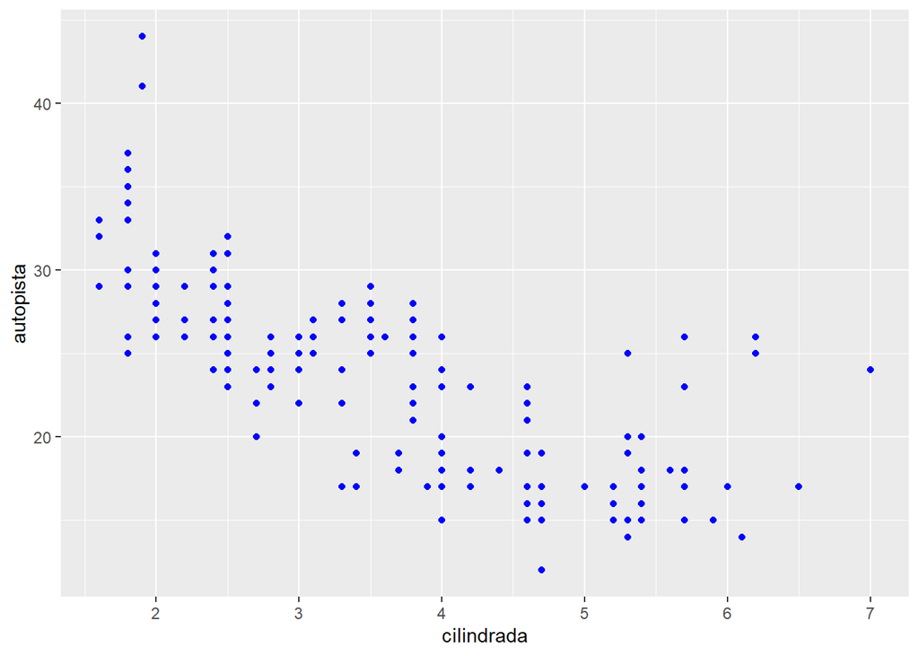

```r
ggplot(data = millas) +
   geom_point(mapping = aes(x = cilindrada, y = autopista), colour = "blue")
```

2. ¿Qué variables en millas son categóricas? ¿Qué variables son continuas? (Pista: escribe ?millas para leer la documentación de ayuda para este conjunto de datos). ¿Cómo puedes ver esta información cuando ejecutas millas?
- Variables categóricas: fabricante, modelo, transmision, traccion, combustible y clase.
- Variables numéricas continuas: cilindrada, ciudad, autopista y discretas: anio, cilindros.

```r
str(millas)
```

```
## tibble [234 x 11] (S3: tbl_df/tbl/data.frame)
##  $ fabricante : chr [1:234] "audi" "audi" "audi" "audi" ...
##  $ modelo     : chr [1:234] "a4" "a4" "a4" "a4" ...
##  $ cilindrada : num [1:234] 1.8 1.8 2 2 2.8 2.8 3.1 1.8 1.8 2 ...
##  $ anio       : int [1:234] 1999 1999 2008 2008 1999 1999 2008 1999 1999 2008 ...
##  $ cilindros  : int [1:234] 4 4 4 4 6 6 6 4 4 4 ...
##  $ transmision: chr [1:234] "auto(l5)" "manual(m5)" "manual(m6)" "auto(av)" ...
##  $ traccion   : chr [1:234] "d" "d" "d" "d" ...
##  $ ciudad     : int [1:234] 18 21 20 21 16 18 18 18 16 20 ...
##  $ autopista  : int [1:234] 29 29 31 30 26 26 27 26 25 28 ...
##  $ combustible: chr [1:234] "p" "p" "p" "p" ...
##  $ clase      : chr [1:234] "compacto" "compacto" "compacto" "compacto" ...
```

```r
?millas
```

```
## starting httpd help server ... done
```

```r
str(millas)
```

```
## tibble [234 x 11] (S3: tbl_df/tbl/data.frame)
##  $ fabricante : chr [1:234] "audi" "audi" "audi" "audi" ...
##  $ modelo     : chr [1:234] "a4" "a4" "a4" "a4" ...
##  $ cilindrada : num [1:234] 1.8 1.8 2 2 2.8 2.8 3.1 1.8 1.8 2 ...
##  $ anio       : int [1:234] 1999 1999 2008 2008 1999 1999 2008 1999 1999 2008 ...
##  $ cilindros  : int [1:234] 4 4 4 4 6 6 6 4 4 4 ...
##  $ transmision: chr [1:234] "auto(l5)" "manual(m5)" "manual(m6)" "auto(av)" ...
##  $ traccion   : chr [1:234] "d" "d" "d" "d" ...
##  $ ciudad     : int [1:234] 18 21 20 21 16 18 18 18 16 20 ...
##  $ autopista  : int [1:234] 29 29 31 30 26 26 27 26 25 28 ...
##  $ combustible: chr [1:234] "p" "p" "p" "p" ...
##  $ clase      : chr [1:234] "compacto" "compacto" "compacto" "compacto" ...
```

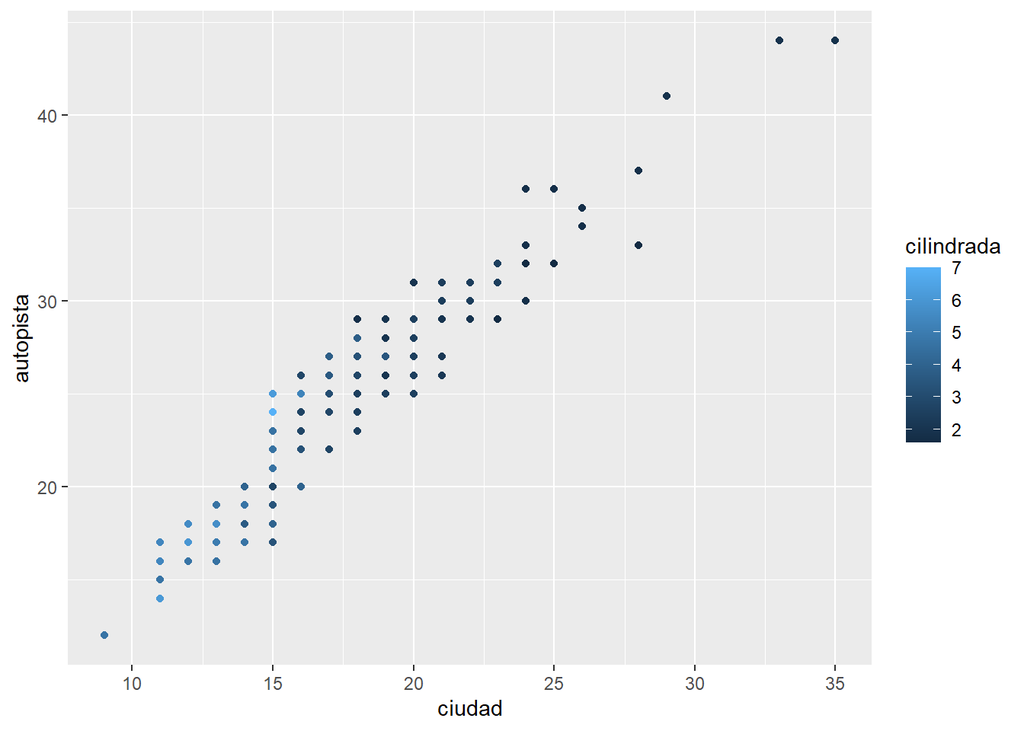

```r
ggplot(data = millas) +
  geom_point(mapping = aes(x = ciudad, y = autopista, color = cilindrada ))
```

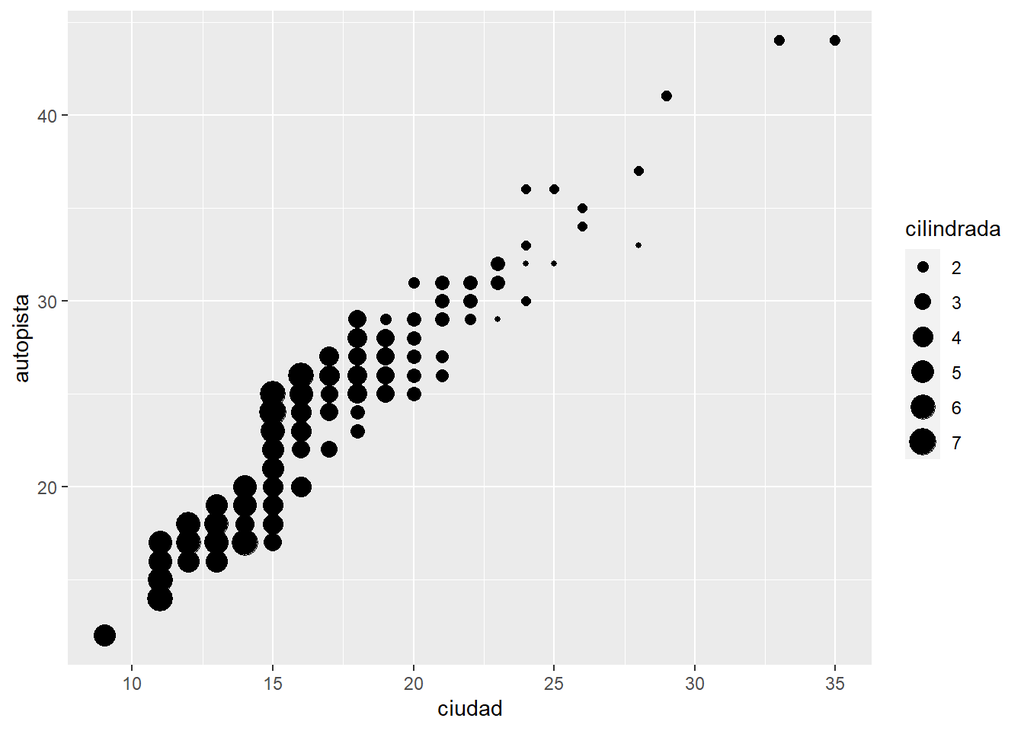

```r
ggplot(data = millas) +
  geom_point(mapping = aes(x = ciudad, y = autopista, size = cilindrada ))
```

Una variable continua no puede ser representada por shape, porque considera sólo 6 valores.

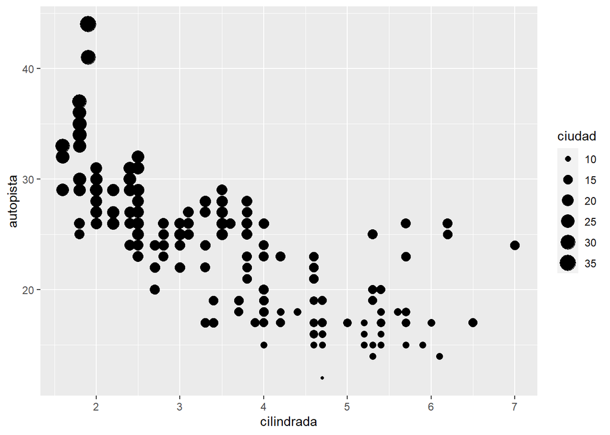

```r
ggplot(data = millas) +
  geom_point(mapping = aes(x = cilindrada, y = autopista, size = ciudad ))
```

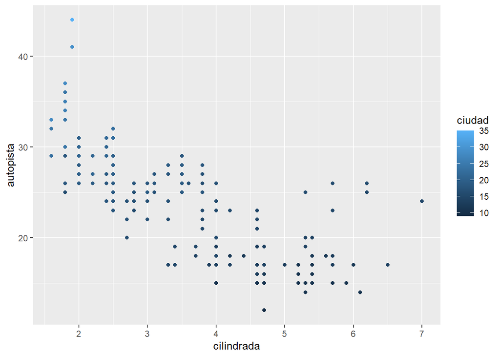

```r
ggplot(data = millas) +
  geom_point(mapping = aes(x = cilindrada, y = autopista, color = ciudad))
```

Tampoco podemos representar con shape la variable ciudad porque los valores que toma esta variable son superiores a los que la estética shape puede considerar.

4. ¿Qué ocurre si asignas o mapeas la misma variable a múltiples estéticas? Se aplican todas las estéticas simultaneamente

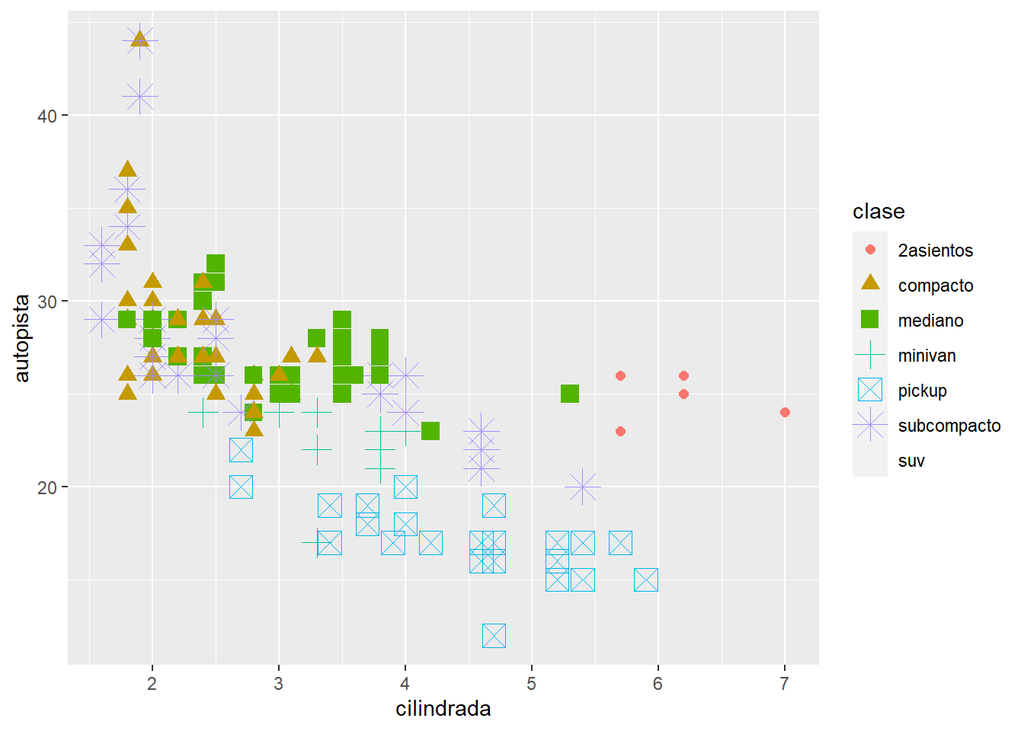

```r
ggplot(data = millas) +
  geom_point(mapping = aes(x = cilindrada, y = autopista, color = clase, shape= clase, size=clase))
```

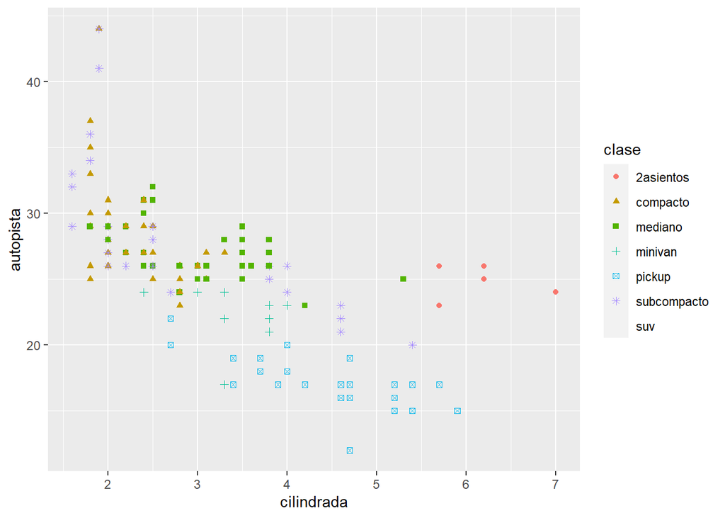

```r
ggplot(data = millas) +
  geom_point(mapping = aes(x = cilindrada, y = autopista, colour = clase, shape = clase))
```

5. ¿Qué hace la estética stroke? ¿Con qué formas trabaja? (Pista: consulta ?geom_point) Define el grosor del trazo.

```r
?geom_point
```

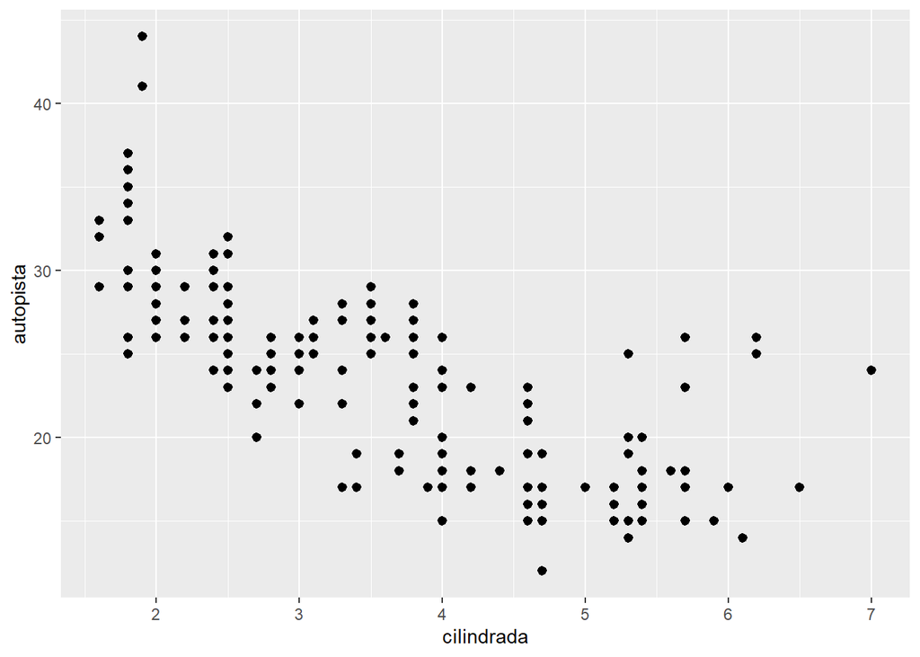

```r
ggplot(data = millas) +
  geom_point(mapping = aes(x = cilindrada, y = autopista, stroke= 1))
```

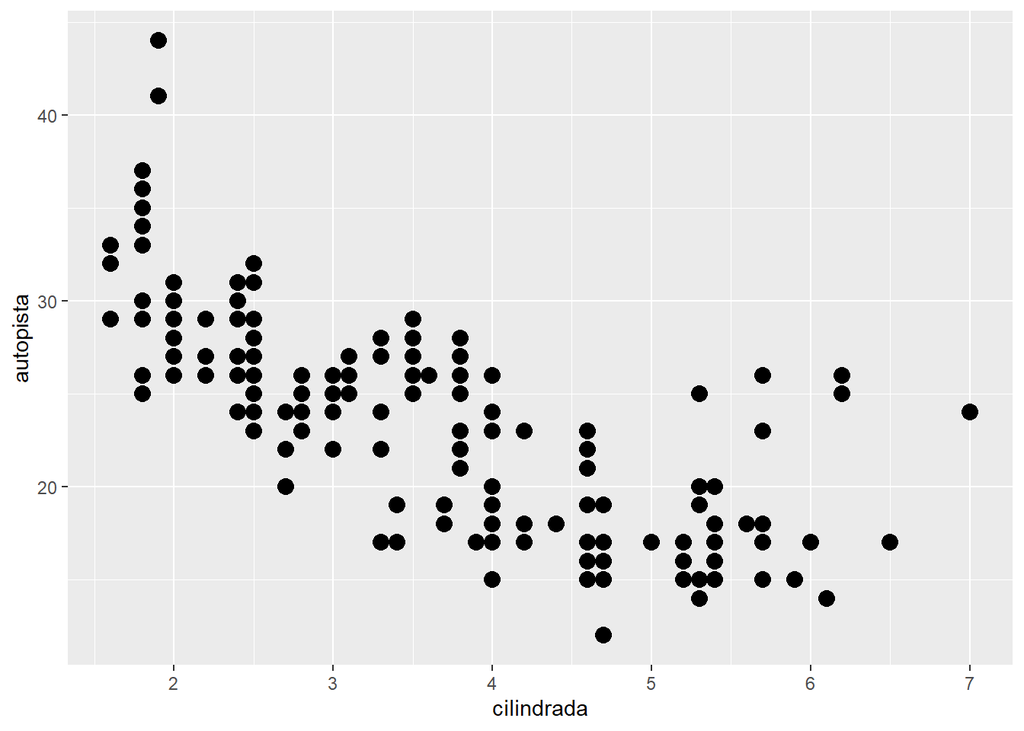

```r
ggplot(data = millas) +
  geom_point(mapping = aes(x = cilindrada, y = autopista, stroke= 2))
```

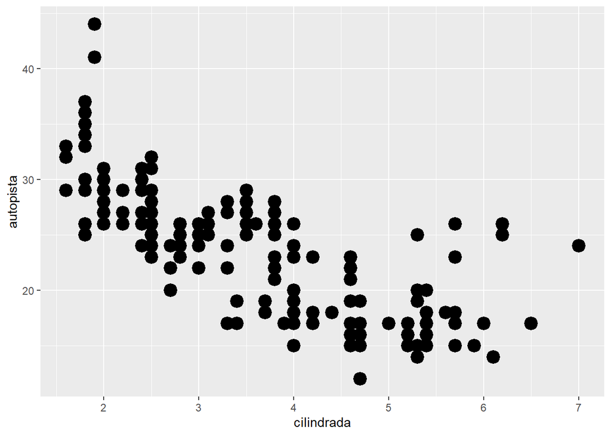

```r
ggplot(data = millas) +
  geom_point(mapping = aes(x = cilindrada, y = autopista, stroke= 3))
```

6. ¿Qué ocurre si se asigna o mapea una estética a algo diferente del nombre de una variable, como aes(color = cilindrada < 5)? Si se asigna una estética a una variable pero además un criterio, la estética discrimana los valores que cumplen ese criterio del resto de los valores de esa variable.

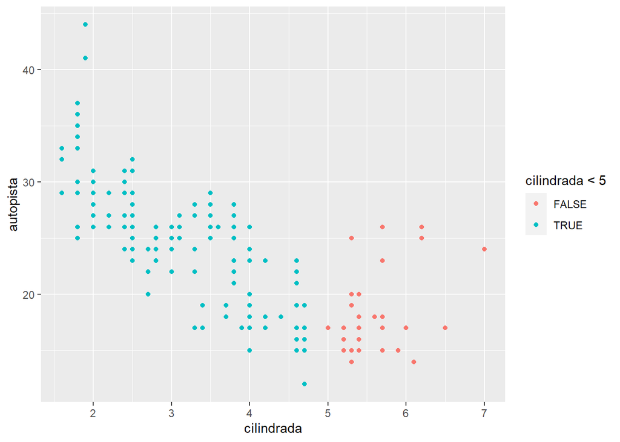

```r
ggplot(data = millas) +
  geom_point(mapping = aes(x = cilindrada, y = autopista, color = cilindrada < 5))
```

## Separar en facetas

##### 3.5.1 Ejercicios

1. ¿Qué ocurre si intentas separar en facetas una variable continua? Se realiza una faceta por cada, valor.

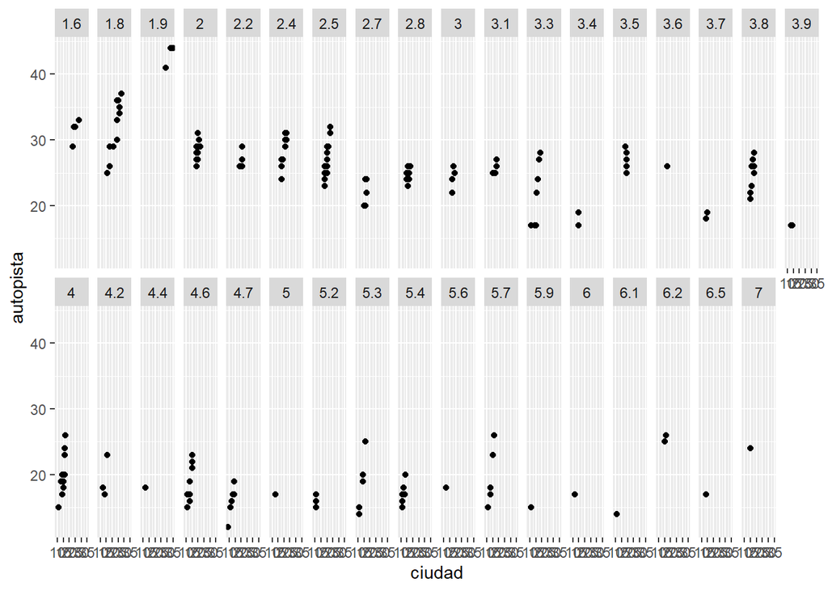

```r
ggplot(data = millas) +
  geom_point(mapping = aes(x = ciudad, y = autopista)) +
  facet_wrap(~ cilindrada, nrow = 2)
```

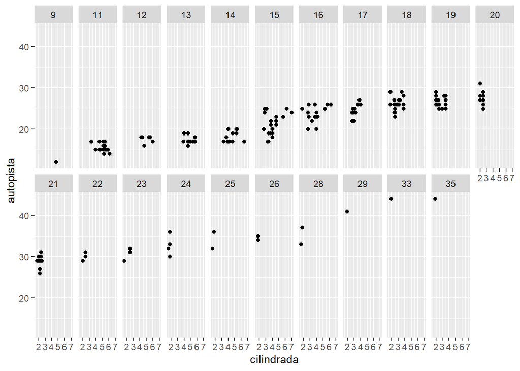

```r
ggplot(data = millas) +
  geom_point(mapping = aes(x = cilindrada, y = autopista)) +
  facet_wrap(~ ciudad, nrow = 2)
```

2. ¿Qué significan las celdas vacías que aparecen en el gráfico generado usando facet_grid(traccion ~ cilindros)? ¿Cómo se relacionan con este gráfico? en los cuadrantes vacíos, no hay valores para la intersección de estas facetas. Y lo podemos observar mejor, en un gráfico de dispersión, que es el gráfico de la segunda pregunta. En este gráfico, podemos ver la relación que existe entre tracción y cilindrados.

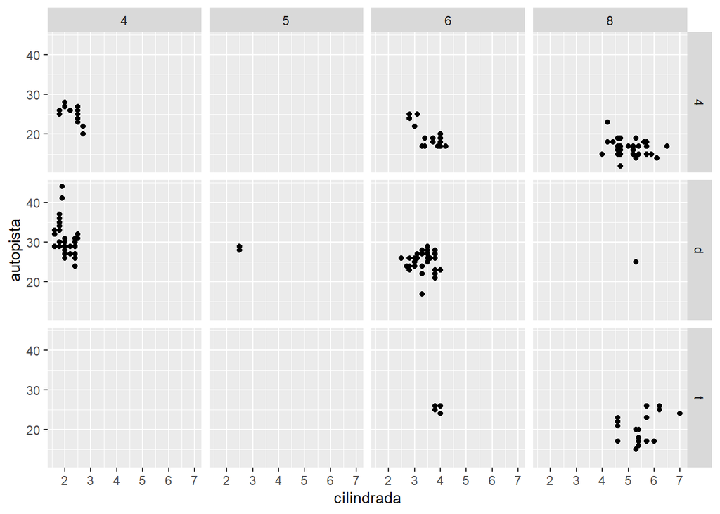

```r
ggplot(data = millas) +
  geom_point(mapping = aes(x = cilindrada, y = autopista)) +
  facet_grid(traccion ~ cilindros)
```

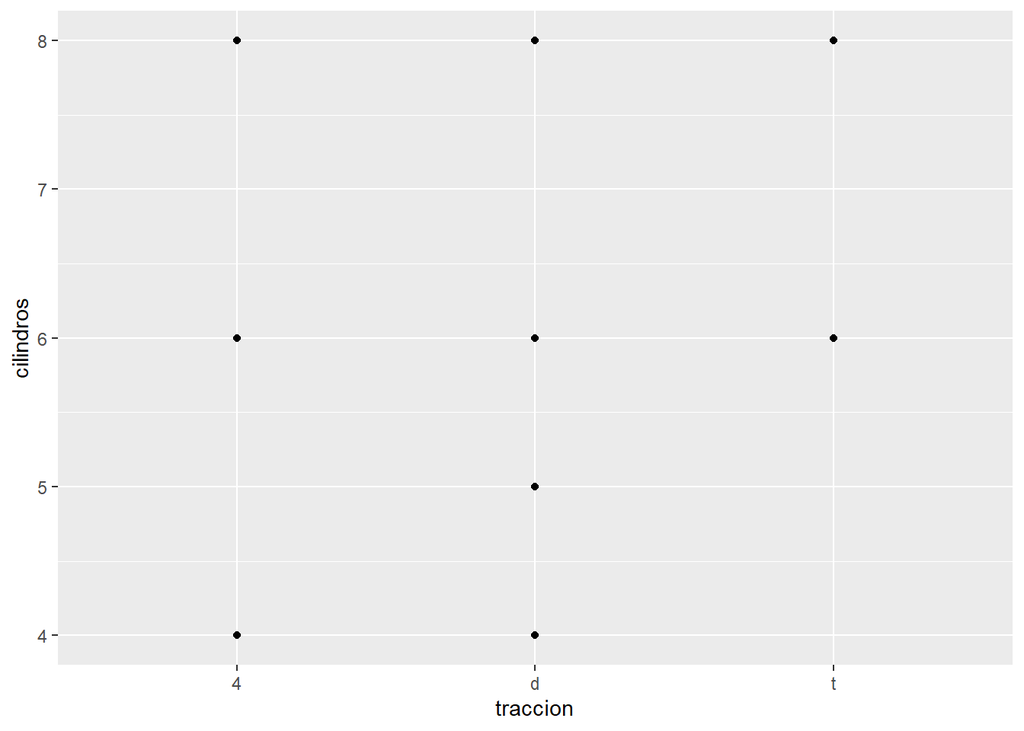

```r
ggplot(data = millas) +
  geom_point(mapping = aes(x = traccion, y = cilindros))
```

3. ¿Qué grafica el siguiente código? ¿Qué hace . ? Al dividir las facetas, el punto a la derecha de la variable categórica significa, que los subgráficos que muestran cada subconjunto de datos se distribuya en forma horizonta, uno debajo del otro. Cuando el punto se encuentra a la izquierda, se distribuyen de forma vertical, uno al lado del otro.

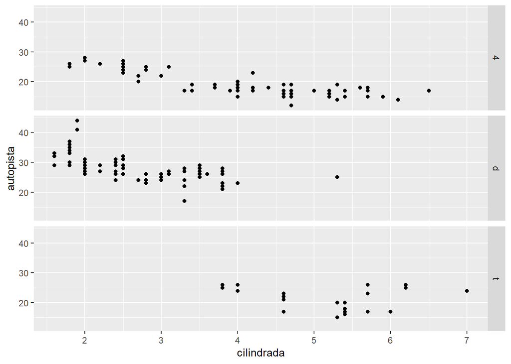

```r
ggplot(data = millas) +
  geom_point(mapping = aes(x = cilindrada, y = autopista)) +
  facet_grid(traccion ~ .)
```

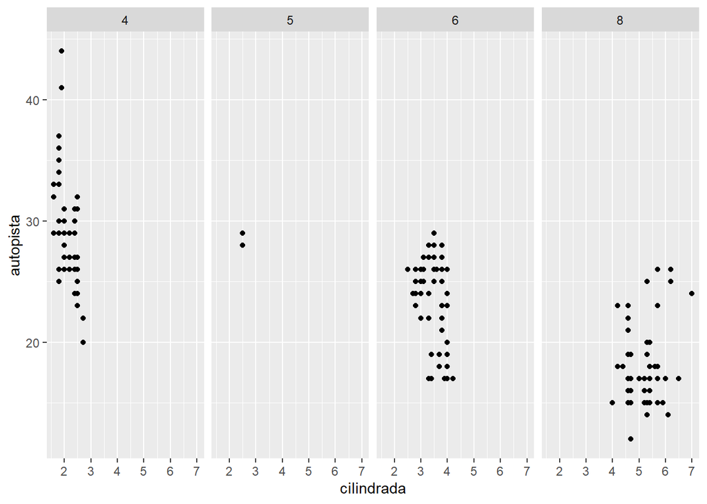

```r
ggplot(data = millas) +
  geom_point(mapping = aes(x = cilindrada, y = autopista)) +
  facet_grid(. ~ cilindros)
```

4. Mira de nuevo el primer gráfico en facetas presentado en esta sección: ¿Cuáles son las ventajas de separar en facetas en lugar de aplicar una estética de color? ¿Cuáles son las desventajas? ¿Cómo cambiaría este balance si tuvieras un conjunto de datos más grande? El gráfico en facetas, permite ver la relación entre x e y para los disitintos niveles de la variable categórica por separado y detectar, de esta manera, si esta variable tiene algún efecto. Como desventaja, observar el gráfico en facetas, no permite ver claramente la dirección, forma y fuerza de la relación entre x e y.

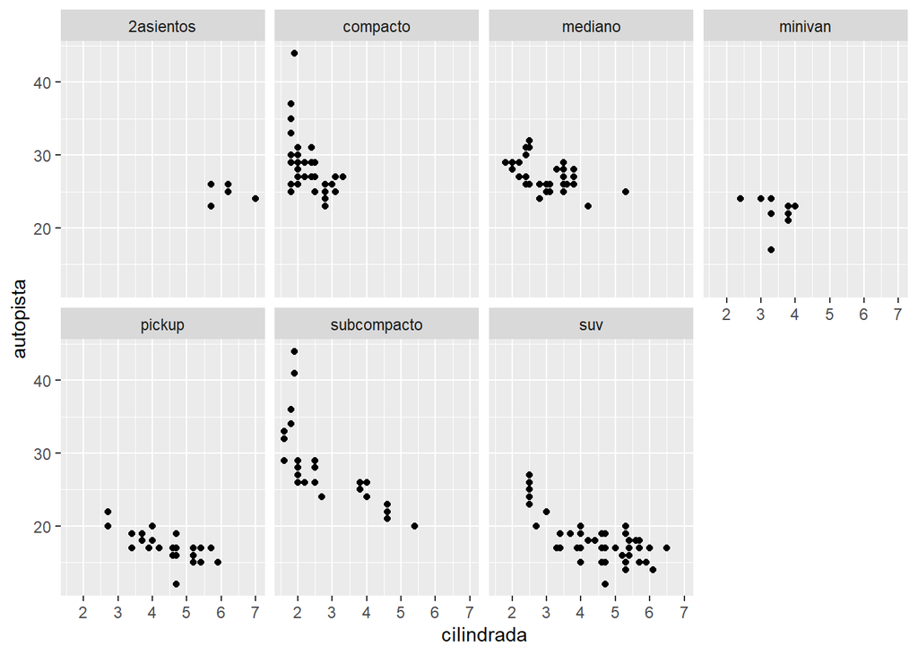

```r
ggplot(data = millas) +
  geom_point(mapping = aes(x = cilindrada, y = autopista)) +
  facet_wrap(~ clase, nrow = 2)
```

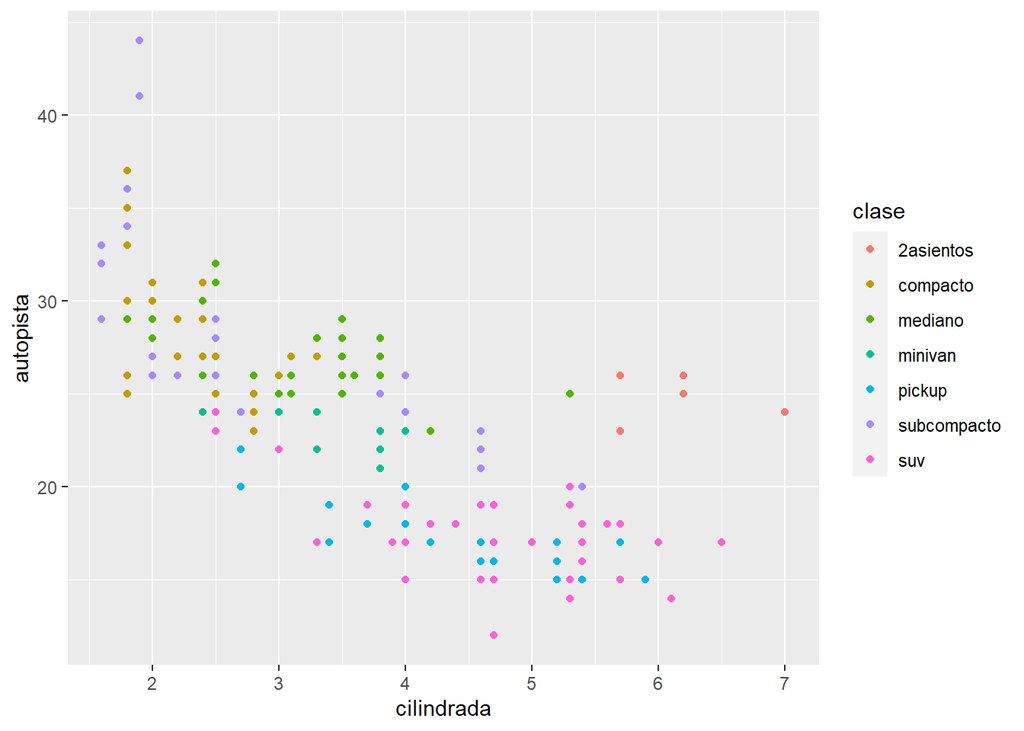

```r
ggplot(data = millas) +
  geom_point(mapping = aes(x = cilindrada, y = autopista, color= clase))
```

5. Lee ?facet_wrap. ¿Qué hace nrow? ¿Qué hace ncol? ¿Qué otras opciones controlan el diseño de los paneles individuales? ¿Por qué facet_grid() no tiene argumentos nrow y ncol? nrow y ncol en facet_warap, indica la cantidad de filas y columnas, respectivamente, en que se ordenan los subgráficos.

```r
?facet_wrap
```

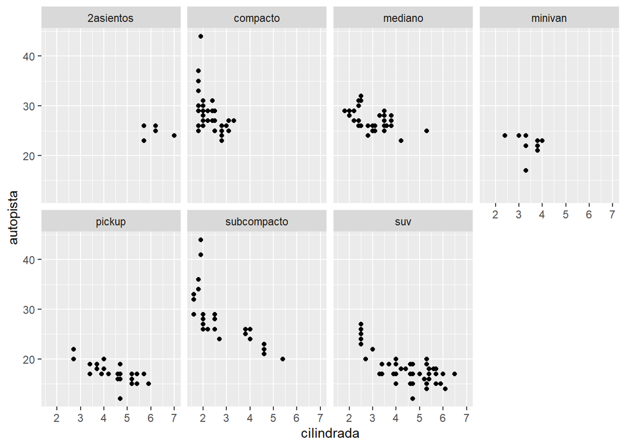

```r
ggplot(data = millas) +
  geom_point(mapping = aes(x = cilindrada, y = autopista)) +
  facet_wrap(~ clase, nrow = 2)
```

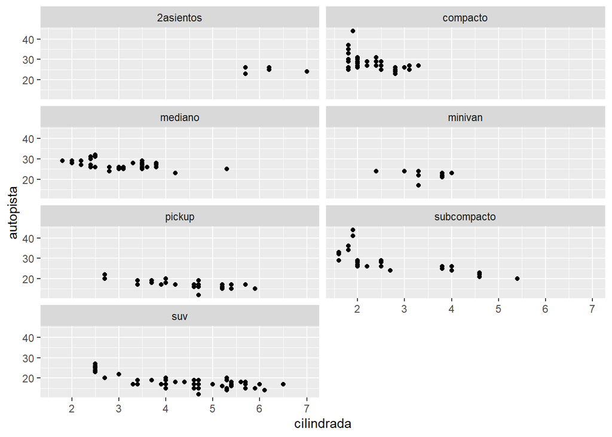

```r
ggplot(data = millas) +
  geom_point(mapping = aes(x = cilindrada, y = autopista)) +
  facet_wrap(~ clase, nrow = 4, ncol = 2)
```

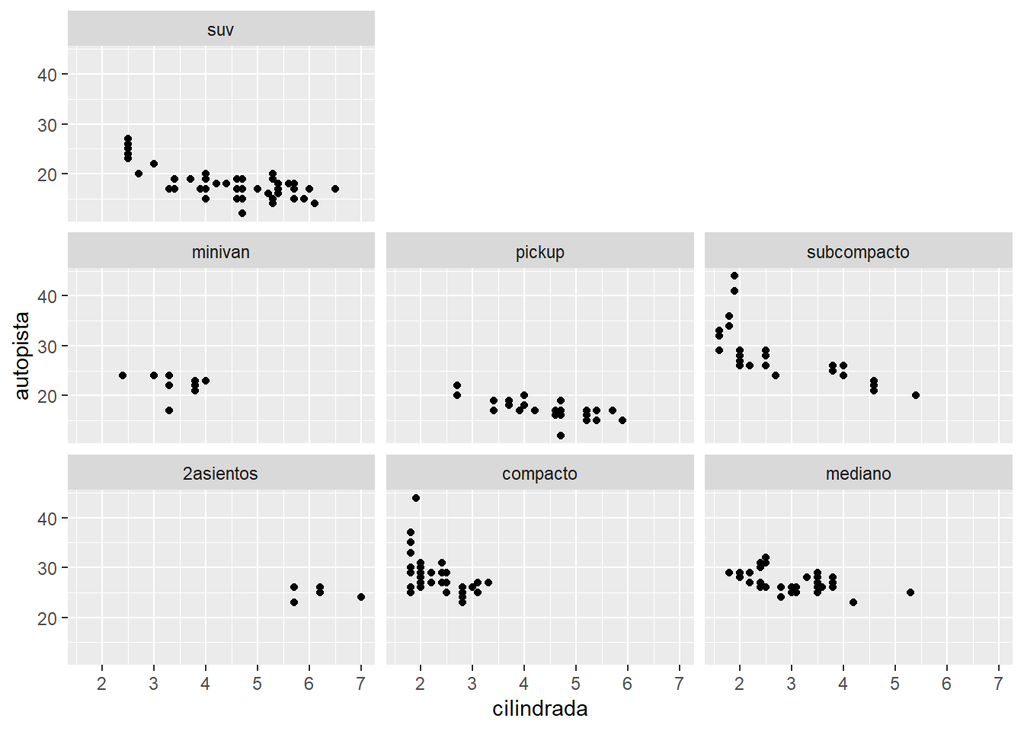

```r
ggplot(data = millas) +
  geom_point(mapping = aes(x = cilindrada, y = autopista)) +
  facet_wrap(~ clase, as.table = F)
```

facet_grid() no tiene argumentos nrow y ncol porque ordena a los subgráfico dado los niveles de las variables categóricas llamadas en la función. La primera variable escrita antes de ~, sus niveles se orden por fila, mientras que la segunda variable, sus niveles se orden por columna.

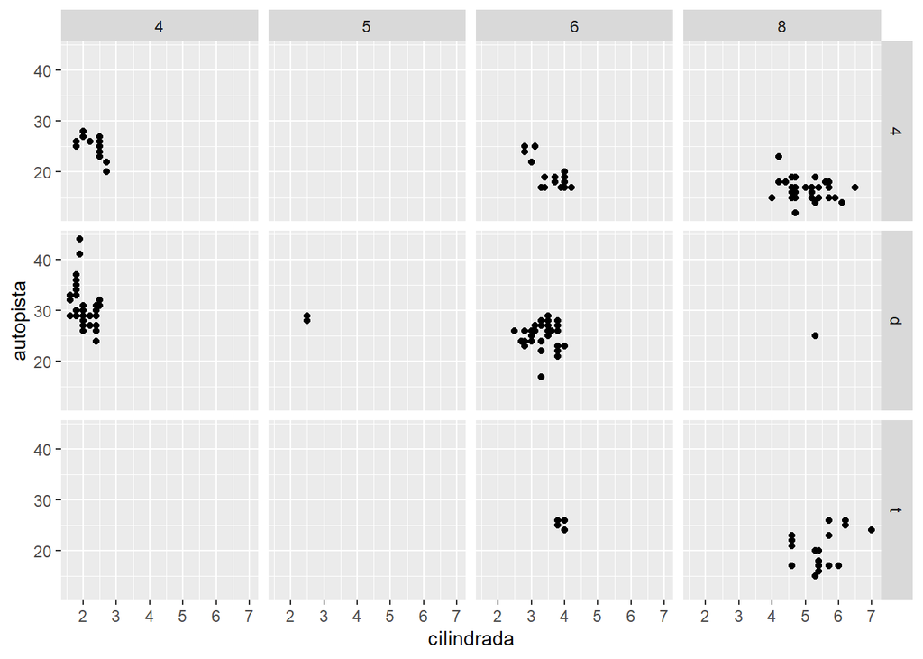

```r
ggplot(data = millas) +
  geom_point(mapping = aes(x = cilindrada, y = autopista)) +
  facet_grid(traccion ~ cilindros)
```

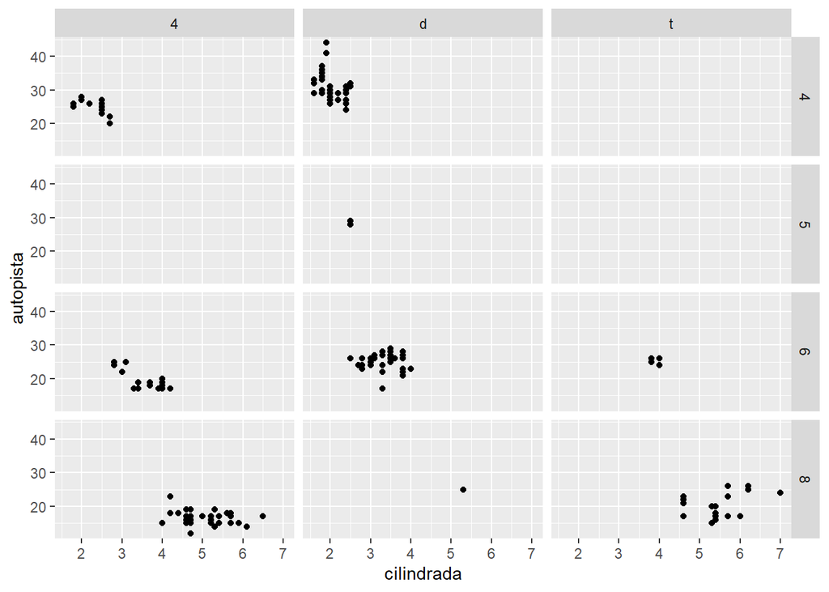

```r
ggplot(data = millas) +
  geom_point(mapping = aes(x = cilindrada, y = autopista)) +
  facet_grid(cilindros ~ traccion)
```

6. Cuando usas facet_grid(), generalmente deberías poner la variable con un mayor número de niveles únicos en las columnas. ¿Por qué? Genera más espacio para las columnas si el gráfico se ubica de forma horizontal.

## Objetos geométricos

##### 3.6.1 Ejercicios

1. ¿Qué geom usarías para generar un gráfico de líneas? ¿Y para un diagrama de caja? ¿Y para un histograma? ¿Y para un gráfico de área? Para un gráfico de líneas geom_line, para un diagrama de caja geom_boxplot, para un histograma geom_histogram, y para un gráfico de área geom_area.

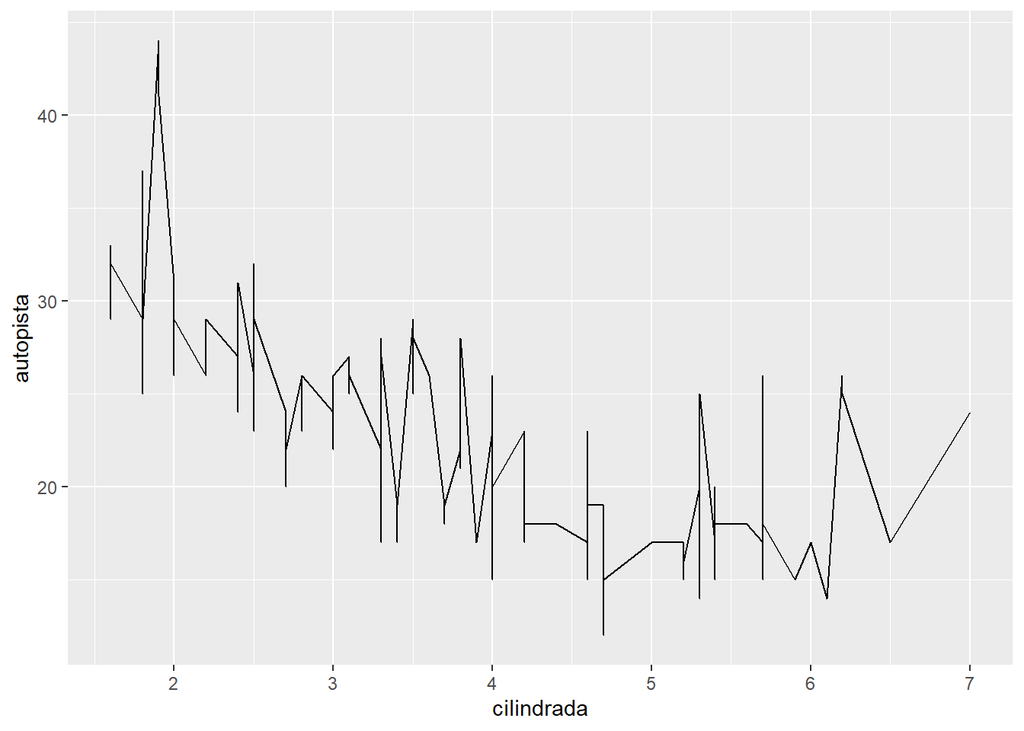

```r
ggplot(data = millas) +
    geom_line(aes(x = cilindrada, y = autopista))
```

```r
#Gráfico de líneas adecuado para x e y continuas
```

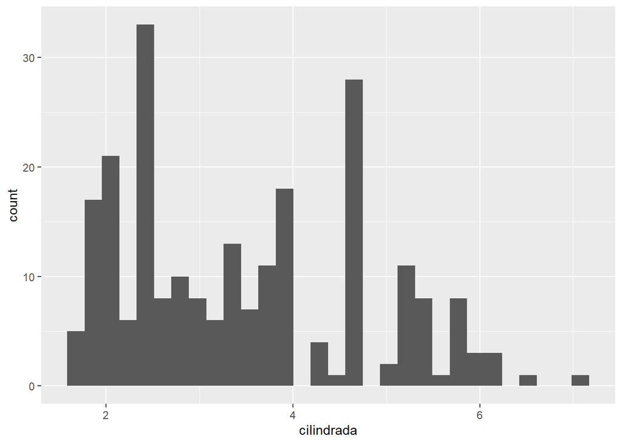

```r
ggplot(data = millas) +
    geom_histogram(aes(x = cilindrada))
```

```r
# Histograma para representar una variables numericas.
```

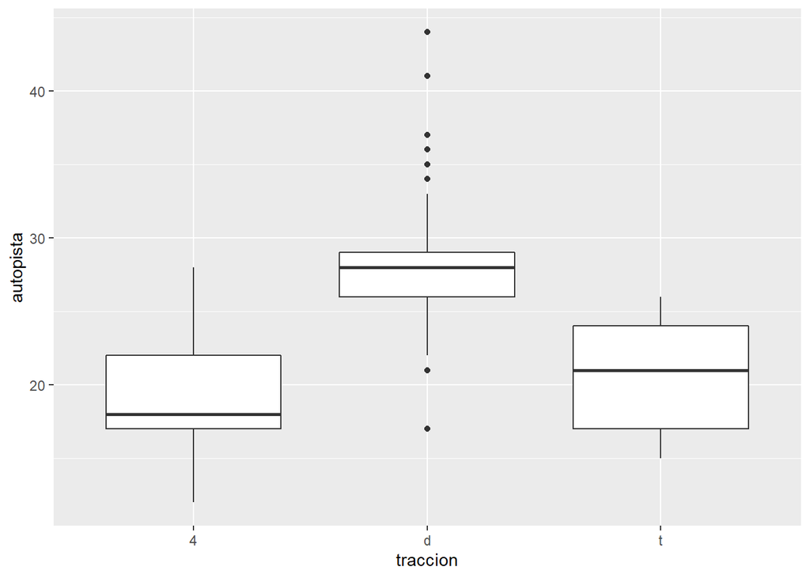

```r
ggplot(data = millas) +
    geom_boxplot(aes(x = traccion, y = autopista))
```

```r
# Gráfico de caja para representar una variable numerica y una variable categórica.
```

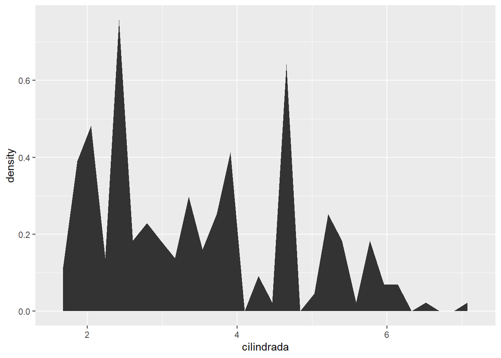

```r
ggplot(data = millas) +
  geom_area(aes(x = cilindrada, y = ..density..), stat = "bin")
```